# **Object-Oriented Programming**

andrés castro araújo

Feb 18, 2020

> All of this is taken from Hadley Wickham’s [**Advanced R**](https://adv-r.hadley.nz). CRC Press, 2019.

## Introduction

Object-oriented programming (OOP) in R can get complicated because there are multiple OOP to choose from. Here we focus on **S3**, **R6**, and **S4**.

> There is disagreement about the relative importance of the OOP systems. I think S3 is most important, followed by R6, then S4. Others believe that S4 is most important, followed by RC, and that S3 should be avoided. This means that different R communities use different systems.

S3 and S4 use **generic function OOP** which is different from the **encapsulated OOP** used in Python.

> S3 allows your functions to return rich results with user-friendly display and programmer-friendly internals. S3 is used throughout base R, so it’s important to master if you want to extend base R functions to work with new types of input.

> R6 provides a standardised way to escape R’s copy-on-modify semantics. This is particularly important if you want to model objects that exist independently of R. Today, a common need for R6 is to model data that comes from a web API, and where changes come from inside or outside of R.

> S4 is a rigorous system that forces you to think carefully about program design. It’s particularly well-suited for building large systems that evolve over time and will receive contributions from many programmers. This is why it is used by the Bioconductor project, so another reason to learn S4 is to equip you to contribute to that project.

People like to use OOP systems because of **polymorphism**.

> Polymorphism means that a developer can consider a function’s interface separately from its implementation, making it possible to use the same function form for different types of input.

In short, it’s what allows functions like `predict()` to work seamlessly with different types of models. It’s also what allows `summary()` to produce different outputs for different variable classes:

```r
summary(iris$Sepal.Length)  ## Numeric
```

```
   Min. 1st Qu.  Median    Mean 3rd Qu.    Max.
  4.300   5.100   5.800   5.843   6.400   7.900
```

```r
summary(iris$Species) ## Factor
```

```
    setosa versicolor  virginica
        50         50         50
```

In every OOP system, objects of different kinds have a different **class**. The implementation for a given class is called a **method**.

> Roughly speaking, a class defines what an object *is* and methods describe what that object can *do*.

> The class defines the **fields**, the data possessed by every instance of that class. Classes are organised in a hierarchy so that if a method does not exist for one class, its parent’s method is used, and the child is said to **inherit** behaviour. […] The process of finding the correct method given a class is called **method dispatch**.

We usually divide OOP systems into two types:

1. **Encapsulated OOP**. Here, methods belong to classes and method calls typically look like this.

   $$\texttt{object.method(arg1, arg2)}$$
2. **Functional OOP**. Here, methods belong to **generic** functions and method calls look like regular function calls:

   $$\texttt{generic(object, arg1, arg2)}$$

## Base Types

```r
library(sloop)
```

When people talk about R objects there’s one potential source of confusion. John Chambers famously said that “Everything that exists in R is an object”. But “while everything *is* an object, not everything is object-oriented”.

> This confusion arises because the base objects come from S, and were developed before anyone thought that S might need an OOP system. The tools and nomenclature evolved organically over many years without a single guiding principle.

Here we distinguish between **base objects** and **OO objects**.

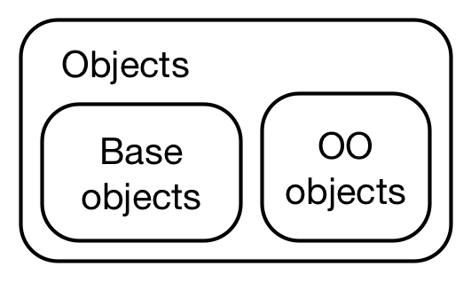

We use `sloop::otype()` to figure out which is which.

```r
otype(1:10)
```

```
[1] "base"
```

```r
otype(iris)
```

```
[1] "S3"
```

> Technically, the difference between base and OO objects is that OO objects have a “class” attribute:

```r
attr(1:10, "class")
```

[output not shown]

```r
attr(iris, "class")
```

```
[1] "data.frame"
```

*Note. The class() function returns misleading results when applied to base objects*

```r
class(1:10)
```

```
[1] "integer"
```

*Base types*

> While only OO objects have a class attribute, every object has a *base type*.

```r
typeof(1:10)
```

```
[1] "integer"
```

```r
typeof(iris)
```

```
[1] "list"
```

> Base types do not form an OOP system because functions that behave differently for different base types are primarily written in C code that uses switch statements.

Here’s an example of R base objects and their C equivalents:

**Vectors**

| R | C |
| --- | --- |
| `NULL` | `NILSXP` |
| `logical` | `LGLSXP` |
| `integer` | `INTSXP` |
| `double` | `REALSXP` |
| `complex` | `CPLXSXP` |
| `character` | `STRSXP` |
| `list` | `VECSXP` |
| `raw` | `RAWSXP` |

```r
typeof(1)
```

```
[1] "double"
```

```r
typeof(1L)
```

```
[1] "integer"
```

```r
typeof(1i)
```

```
[1] "complex"
```

**Functions**

| R | C |
| --- | --- |
| `closure` | `CLOSXP` |
| `special` | `SPECIALSXP` |
| `builtin` | `BUILTINSXP` |

```r
typeof(sum)
```

```
[1] "builtin"
```

```r
typeof(`<-`)
```

```
[1] "special"
```

```r
typeof(mean)
```

```
[1] "closure"
```

*In total, there are 25 different base types.*

A final note.

R users talk about a “numeric” type, which has become a permanent source of confusion for some of us. This is because “numeric” has at least three different meanings in R:

1. Sometimes “numeric” is synonymous with “double” (e.g. `as.numeric()` is identical to `as.double()`)
2. S3 and S4 systems use “numeric” for picking methods that work with either “double” or “integer” types.

```r
sloop::s3_class(1)
```

```
[1] "double"  "numeric"
```

```r
sloop::s3_class(1L)
```

```
[1] "integer" "numeric"
```

3. Finally, we are sometimes interested in objects that behave like numbers. For example, factors are of type “integer” but don’t behave like numbers.

```r
typeof(iris$Species)
```

```
[1] "integer"
```

```r
is.numeric(iris$Species)
```

```
[1] FALSE
```

## S3

S3 is R’s first and most used Object-Oriented system (it’s used in the `base` and `stats` packages). It’s minimalist. You should use it, unless you have a compelling reason to do otherwise.

> Since S3 has few built-in constraints, the key to its successful use is applying the constraints yourself.
- An S3 object is a base type with *at least* one `class` attribute.

  For example, factors are integer types that have a `class` attribute “factor” and also a “levels” attribute.

  ```r
  fx <- factor(c("b", "a", "c"))
  fx
  ```

  ```
  [1] b a c
  Levels: a b c
  ```

  ```r
  typeof(fx)
  ```

  ```
  [1] "integer"
  ```

  ```r
  attributes(fx)
  ```

  ```
  $levels
  [1] "a" "b" "c"

  $class
  [1] "factor"
  ```

  If you `unclass()` a factor, it will lose it’s special behavior.

  ```r
  unclass(fx)  ## equivalent to attr(fx, "class") <- NULL
  ```

  ```
  [1] 2 1 3
  attr(,"levels")
  [1] "a" "b" "c"
  ```

- An S3 object behaves differently from its underlying base type whenever it’s passed to a **generic function**.

  > A generic function defines an interface, which uses a different implementation depending on the class of an argument (almost always the first argument).

  For example, the ubiquitous `str` and `print` functions are generic.

  ```r
  sloop::ftype(str)
  ```

  ```
  [1] "S3"      "generic"
  ```

  ```r
  str(fx)
  ```

  ```
   Factor w/ 3 levels "a","b","c": 2 1 3
  ```

  ```r
  str(unclass(fx))
  ```

  ```
   int [1:3] 2 1 3
   - attr(*, "levels")= chr [1:3] "a" "b" "c"
  ```

  > The generic is a middleman: its job is to define the interface (i.e. the arguments) then find the right implementation for the job. The implementation for a specific class is called a **method**, and the generic finds that method by performing **method dispatch**.
- All S3 methods are functions with a special naming scheme: `generic.class()`.

  ```r
  print.factor(fx)
  ```

  ```
  [1] b a c
  Levels: a b c
  ```

  But you should never call the method directly, instead rely on the generic to find the right function for you.

*Exercises.*

> Make a list of commonly used base R functions that contain `.` in their name but are *not* S3 methods.

Many functions in base R are point-separated, even though they are not `generic.method()` functions. They were written before S3. We can check if they’re *methods* using `sloop::ftype()`.

```r
sloop::ftype(print.factor)
```

```
[1] "S3"     "method"
```

```r
sloop::ftype(t.test)
```

```
[1] "S3"      "generic"
```

```r
sloop::ftype(is.factor)
```

```
[1] "function"
```

Here’s a list of common point-separated functions that are *not* methods:

```r
install.packages()
read.csv()
list.files()
download.file()
data.frame()
as.character()
Sys.Date()
all.equal()
do.call()
on.exit()
```

Unsurprisingly, many of these functions have “tidyverse” replacements that eliminate this ambiguity (e.g. `readr::read_csv()`).

### Classes

S3 has no formal definition of **class**. To make an object an instance of a class, you simply set the *class attribute*.

```r
# Create and assign class in one step
x <- structure(list(), class = "my_class") ## you can set any attribute here

# Create, then set class
x <- list()
class(x) <- "my_class"
```

> You can determine the class of an S3 object with `class(x)`, and see if an object is an instance of a class using `inherits(x, "classname")`.

```r
class(x)
```

```
[1] "my_class"
```

```r
inherits(x, "my_class")
```

```
[1] TRUE
```

> S3 has no checks for correctness which means you can change the class of existing objects:

```r
# Create a linear model
mod <- lm(log(mpg) ~ log(disp), data = mtcars)
class(mod)
```

```
[1] "lm"
```

```r
print(mod)
```

```
Call:
lm(formula = log(mpg) ~ log(disp), data = mtcars)

Coefficients:
(Intercept)    log(disp)
     5.3810      -0.4586
```

```r
# Turn it into a date (?!)
class(mod) <- "Date"

# Unsurprisingly this doesn't work very well
print(mod)
```

```
Error in as.POSIXlt.Date(x): (list) object cannot be coerced to type 'double'
```

```r
# Turning it back to normal
class(mod) <- "lm"
print(mod)
```

```
Call:
lm(formula = log(mpg) ~ log(disp), data = mtcars)

Coefficients:
(Intercept)    log(disp)
     5.3810      -0.4586
```

In practice, this immense flexibility shouldn’t cause any problems.

> R doesn’t stop you from shooting yourself in the foot, but as long as you don’t aim the gun at your toes and pull the trigger, you won’t have a problem.

Wickham recommends having three functions when constructing new classes:

1. A low-level **constructor**, `new_myclass()`, that efficiently creates new objects with the correct structure. You should *always* provide a constructor.
2. A **validator**, `validate_myclass()`, that performs more computationally expensive checks to ensure that the object has correct values.
3. A user-friendly **helper**, `myclass()`, that provides a convenient way for others to create objects of your class.

#### **Constructors**

The S3 system has no way to ensure that all objects of a given class have the same structure (i.e. “the same base type and the same attributes with the same types”). This is why we should use constructors to *enforce* a consistent structure.

In general, these constructors should follow the same basic principles:

- They should have one argument for the base object, and one for each attribute.
- They should check the type of the base object and the types of each attribute.

*Example: The S3 `Date` class.*

```r
new_Date <- function(x = double()) {
  stopifnot(is.double(x))
  structure(x, class = "Date")
}

class(new_Date(0))
```

```
[1] "Date"
```

*Example: The S3 `difftime` class.*

```r
new_difftime <- function(x = double(), units = "secs") {
  stopifnot(is.double(x))
  units <- match.arg(units, c("secs", "mins", "hours", "days", "weeks"))

  structure(x,
    class = "difftime",
    units = units
  )
}

new_difftime(c(1, 4, 12), units = "week")
```

```
Time differences in weeks
[1]  1  4 12
```

```r
new_difftime(0, units = "mins")
```

```
Time difference of 0 mins
```

> The constructor is a developer function: it will be called in many places, by an experienced user. That means it’s OK to trade a little safety in return for performance, and you should avoid potentially time-consuming checks in the constructor.

#### **Validators**

Constructors only check that types are correct. But some classes require complicated checks for validity.

*Example: The S3 `factor` class.*

```r
new_factor <- function(x = integer(), levels = character()) {
  stopifnot(is.integer(x))
  stopifnot(is.character(levels))

  structure(x, class = "factor", levels = levels)
}

new_factor(1:5, "a")
```

```
Error in as.character.factor(x): malformed factor
```

> Rather than encumbering the constructor with complicated checks, it’s better to put them in a separate function. Doing so allows you to cheaply create new objects when you know that the values are correct, and easily re-use the checks in other places.

```r
validate_factor <- function(x) {
  values <- unclass(x)
  levels <- attr(x, "levels")

  if (!all(!is.na(values) & values > 0)) {
    stop(
      "All `x` values must be non-missing and greater than zero",
      call. = FALSE
    )
  }

  if (length(levels) < max(values)) {
    stop(
      "There must be at least as many `levels` as possible values in `x`",
      call. = FALSE
    )
  }
  x
}

validate_factor(new_factor(0:1, "a"))
```

```
Error: All `x` values must be non-missing and greater than zero
```

```r
validate_factor(new_factor(1:5, "a"))
```

```
Error: There must be at least as many `levels` as possible values in `x`
```

#### **Helpers**

Helpers strive to make the life of end users as easy as possible.

A helper should always:

1. *Have the same name as the class, e.g. `myclass()`.*
2. *Finish by calling the constructor, and the validator, if it exists.*
3. *Create carefully crafted error messages tailored towards an end-user.*
4. *Have a thoughtfully crafted user interface with carefully chosen default values and useful conversions.*

It’s hard to give any general advice for this last bullet point, but Wickham does note three common patterns:

- *Sometimes all the helper needs to do is coerce its inputs to the desired type.*

  ```r
  new_difftime(1:10)
  ```

  ```
  Error in new_difftime(1:10): is.double(x) is not TRUE
  ```

  > It’s not the job of the constructor to be flexible, so here we create a helper that just coerces the input to a double.

  ```r
  difftime <- function(x = double(), units = "secs") {
    x <- as.double(x)
    new_difftime(x, units = units)
  }

  difftime(1:10)
  ```

  ```
  Time differences in secs
   [1]  1  2  3  4  5  6  7  8  9 10
  ```

- *Often, the most natural representation of a complex object is a string. For example, it’s very convenient to specify factors with a character vector.*

  ```r
  factor <- function(x = character(), levels = unique(x)) {
    # match returns a vector of the positions of (first) matches of its first
    # argument in its second.
    ind <- match(x, levels)
    validate_factor(new_factor(ind, levels))
  }

  x <- sample(letters[1:5], 10, replace = TRUE)
  factor(x)
  ```

  ```
   [1] d c e b c d d c d c
  Levels: d c e b
  ```

- *Some complex objects are most naturally specified by multiple simple components.*

  > For example, it’s natural to construct a date-time by supplying the individual components (year, month, day etc). That leads to this `POSIXct()` helper that resembles the existing `ISODatetime()` function:

  ```r
  POSIXct <- function(year = integer(),
                      month = integer(),
                      day = integer(),
                      hour = 0L,
                      minute = 0L,
                      sec = 0,
                      tzone = "") {
    ISOdatetime(year, month, day, hour, minute, sec, tz = tzone)
  }

  POSIXct(2020, 1, 1, tzone = "America/New_York")
  ```

  ```
  [1] "2020-01-01 EST"
  ```

*Exercises*

> Write a constructor for data.frame objects. What base type is a data frame built on? What attributes does it use? What are the restrictions placed on the individual elements? What about the names?

Data frames are built on top of named lists of vectors. Besides `class`, it has column `names` and `row.names` for attributes.

```r
typeof(mtcars)
```

```
[1] "list"
```

```r
attributes(mtcars) %>% str()
```

```
List of 3
 $ names    : chr [1:11] "mpg" "cyl" "disp" "hp" ...
 $ row.names: chr [1:32] "Mazda RX4" "Mazda RX4 Wag" "Datsun 710" "Hornet 4 Drive" ...
 $ class    : chr "data.frame"
```

A `data.frame` constructor:

```r
new_data.frame <- function(x = list(), row.names = NULL) {
  stopifnot(is.list(x))

  # Check all inputs are the same length
  rows <- unique(lengths(x))
  stopifnot(length(rows) <= 1)  ## allows data frames with 0 rows

  if (is.null(row.names)) {
     row.names <- if (length(rows) == 0) integer() else seq_along(1:rows)
   } else {
     stopifnot(is.character(row.names),
               length(row.names) == unique(lengths(x)))
   }

  structure(x, class = "data.frame", row.names = row.names)
}

new_data.frame()
```

```
data frame with 0 columns and 0 rows
```

```r
new_data.frame(list(c1 = 1:2, c2 = 2:3))
```

```
  c1 c2
1  1  2
2  2  3
```

```r
new_data.frame(list(c1 = 1:2, c2 = 2:3), row.names = c("a", "b"))
```

```
  c1 c2
a  1  2
b  2  3
```

> Read the documentation for utils::as.roman(). How would you write a constructor for this class? Does it need a validator? What might a helper do?

`as.roman` turns integer numbers into roman numerals. It creates an object of class “roman”.

```r
r <- as.roman(1:5)
attributes(r)
```

```
$class
[1] "roman"
```

```r
new_roman <- function(x = integer()) {
  stopifnot(is.integer(x))
  structure(x, class = "roman")
}

r <- new_roman(1:5)
r
```

```
[1] I   II  III IV  V
```

```r
r^2
```

```
[1] I   IV  IX  XVI XXV
```

It needs a validator because "only numbers between 1 and 3899 have a unique representation as roman numbers, and hence others result in `as.roman(NA)`.

```r
validate_roman <- function(x) {
  values <- unclass(x)

  if (any(values < 1 | values > 3899)) {
    stop(
      "Roman numbers must fall between 1 and 3899.",
      call. = FALSE
    )
  }
  x
}

validate_roman(4000L)
```

```
Error: Roman numbers must fall between 1 and 3899.
```

A helper function could be used to coerce real numbers into integers.

```r
roman <- function(x = integer()) {
  x <- as.integer(x)
  validate_roman(new_roman(x))
}

roman(rpois(5, 100))
```

```
[1] LXXXIV XCI    CIX    CXII   XCVI
```

### Generics and methods

S3 generic functions perform **method dispatch**: they find the specific implementation for a given class. This gets done by using the `UseMethod()` function, which is called by every generic (with the exception of *internal generics*).

> `UseMethod()` takes two arguments: the name of the generic function (required), and the argument to use for method dispatch (optional). If you omit the second argument, it will dispatch based on the first argument, which is almost always what is desired.

For example:

```r
print
```

```
function (x, ...)
UseMethod("print")
<bytecode: 0x7fcb2784b800>
<environment: namespace:base>
```

```r
mean
```

```
function (x, ...)
UseMethod("mean")
<bytecode: 0x7fcb26da08d8>
<environment: namespace:base>
```

Thus, creating a new generic is a simple as this:

```r
my_new_generic <- function(x) {
  UseMethod("my_new_generic")
}
```

> When a function calling `UseMethod("fun")` is applied to an object with class attribute `c("first", "second")`, the system searches for a function called `fun.first` and, if it finds it, applies it to the object. If no such function is found a function called `fun.second` is tried. If no class name produces a suitable function, the function `fun.default` is used, if it exists, or an error results.

```r
my_new_generic(1L)
```

```
Error in UseMethod("my_new_generic"): no applicable method for 'my_new_generic' applied to an object of class "c('integer', 'numeric')"
```

In the above example, `1L` has an implicit class `c("integer", "numeric")`.

> Most vectors have class the result of `mode(x)`, except that integer vectors have class `c("integer", "numeric")` and real vectors have class `c("double", "numeric")`.

**How does method dispatch actually work?**

`UseMethod()` basically creates a vector of method names, and then looks for each potential method in turn.

```r
paste0("generic", ".", c(class(x), "default"))
```

This can create some very weird bugs if you are not careful about class names. For example, by creating a vector of class “test” and then calling the `t()` function for matrix transposition, we end up calling the unrelated `t.test()` function.

```r
x <- structure(1:10, class = "test")
t(x)
```

```
    One Sample t-test

data:  x
t = 5.7446, df = 9, p-value = 0.0002782
alternative hypothesis: true mean is not equal to 0
95 percent confidence interval:
 3.334149 7.665851
sample estimates:
mean of x
      5.5
```

This is the most compelling reason to why you should *never* use `.`’s in function names.

We can see method dispatch in action with the `sloop::s3_dispatch()` function, which lists all possible methods when you call an S3 generic inside of it.

```r
x <- Sys.Date()
s3_dispatch(print(x))
```

```
=> print.Date
 * print.default
```

Here, `=>` indicates the method that is called, whereas `*` indicates a method that is not called, even though it is defined.

> The “default” class is a special **pseudo-class.** This is not a real class, but is included to make it possible to define a standard fallback that is found whenever a class-specific method is not available.

> `sloop::s3_dispatch()` lets you find the specific method used for a single call. What if you want to find all methods defined for a generic or associated with a class? That’s the job of `sloop::s3_methods_generic()` and `sloop::s3_methods_class()`:

```r
s3_methods_generic("mean")  # similar to methods()
```

```
# A tibble: 7 x 4
  generic class      visible source
  <chr>   <chr>      <lgl>   <chr>
1 mean    Date       TRUE    base
2 mean    default    TRUE    base
3 mean    difftime   TRUE    base
4 mean    POSIXct    TRUE    base
5 mean    POSIXlt    TRUE    base
6 mean    quosure    FALSE   registered S3method
7 mean    vctrs_vctr FALSE   registered S3method
```

```r
s3_methods_class("table")
```

```
# A tibble: 11 x 4
   generic       class visible source
   <chr>         <chr> <lgl>   <chr>
 1 [             table TRUE    base
 2 aperm         table TRUE    base
 3 as.data.frame table TRUE    base
 4 Axis          table FALSE   registered S3method
 5 head          table FALSE   registered S3method
 6 lines         table FALSE   registered S3method
 7 plot          table FALSE   registered S3method
 8 points        table FALSE   registered S3method
 9 print         table TRUE    base
10 summary       table TRUE    base
11 tail          table FALSE   registered S3method
```

*Exercises.*

> Which base generic has the greatest number of defined methods?

```r
objs <- rlang::pkg_env("base") %>% as.list()
objs <- objs[map_lgl(objs, is.function)]
objs <- objs[map_lgl(names(objs), sloop::is_s3_generic)]
generic_function_names <- names(objs)

library(dplyr)

number_of_methods <- function(x) {
  s3_methods_generic(x) %>%
    #filter(source == "base") %>% ## the number of methods can depend on the number
    nrow()                      ## of packages attached to the search path
}

tibble::tibble(fname = generic_function_names) %>%
  mutate(n = map_int(fname, number_of_methods)) %>%
  arrange(desc(n))
```

```
# A tibble: 169 x 2
   fname             n
   <chr>         <int>
 1 print           274
 2 format          103
 3 [                47
 4 summary          37
 5 as.data.frame    33
 6 as.character     32
 7 [[               23
 8 $                16
 9 c                15
10 as.list          15
# … with 159 more rows
```

> Carefully read the documentation for `UseMethod()` and explain why the following code returns the results that it does.

```r
g <- function(x) {
  x <- 10
  y <- 10
  UseMethod("g")
}

g.default <- function(x) { c(x = x, y = y) }

x <- 1
y <- 1

g.default(1)
```

```
x y
1 1
```

```r
g(1)
```

```
 x  y
 1 10
```

Calling `g.default(x = 1)` retrieves `y` from the global environment. But typing `g()` retrieves `y` from the environment enclosed by `g()`, similar to what would happen if `g()` was a function factory.

> What are the arguments to `[`? Why is this a hard question to answer?

The subsetting operator `[` is both “primitive” and “generic”. Thus, we can’t really take a look into its arguments. We can, however, take a look at some of the methods it implements.

```r
ftype(`[`)
```

```
[1] "primitive" "generic"
```

```r
formals(`[.factor`)
```

```
$x


$...


$drop
[1] FALSE
```

```r
formals(`[.Date`)
```

```
$x


$...


$drop
[1] TRUE
```

```r
formals(`[.table`)
```

```
$x


$i


$j


$...


$drop
[1] TRUE
```

```r
formals(`[.numeric_version`)
```

[output not shown]

It’s very likely that `[`’s arguments are just `x` and `...`. But we can’t know for sure unless we inspect the underlying C code.

### Object styles

**Vector style** classes like `Factor` and `Date` have one key property: *`length(x)` represents the number of observations in the the vector*.

There are three object styles that don’t have this property:

- **Record style** objects use a list of equal-length vectors to represent individual components of the object. For example, `POSIXlt` is a list of 11 date-time components: year, month, day, hour, min, sec, etc.

  ```r
  x <- as.POSIXlt(c("2020-01-01", "2020-01-02"))
  str(unclass(x))
  ```

  ```
  List of 11
   $ sec   : num [1:2] 0 0
   $ min   : int [1:2] 0 0
   $ hour  : int [1:2] 0 0
   $ mday  : int [1:2] 1 2
   $ mon   : int [1:2] 0 0
   $ year  : int [1:2] 120 120
   $ wday  : int [1:2] 3 4
   $ yday  : int [1:2] 0 1
   $ isdst : int [1:2] 0 0
   $ zone  : chr [1:2] "EST" "EST"
   $ gmtoff: int [1:2] NA NA
  ```

  Record style classes override `length()` and subsetting methods to conceal this implementation detail.

  ```r
  length(x)
  ```

  ```
  [1] 2
  ```

  ```r
  x[[1]]
  ```

  ```
  [1] "2020-01-01 EST"
  ```

- **Data frames** are similar to record style objects in that both use lists of equal length vectors. But data frames are two dimensional, and the individual components are readily exposed to the user. The number of observations is given by `nrow(df)`, whereas `length(df)` gives us the number of columns.
- **Scalar objects** typically use a list to represent one single thing. For example, an `lm` object is actually a list of length 12, even though it represents one model.

*Exercises.*

> Categorise the objects returned by `lm()`, `factor()`, `table()`, `as.Date()`, `as.POSIXct()`, `ecdf()`, `ordered()`, `I()` into the styles described above.

| object from | style |
| --- | --- |
| `lm()` | scalar |
| `ecdf()` | scalar |
| `table()` | vector |
| `as.Date()` | vector |
| `as.POSIXct()` | vector |
| `as.POSIXlt()` | record |
| `I()` | `other` |

### Inheritance

> S3 classes can share behaviour through a mechanism called **inheritance**.

This mechanism is powered by three things:

- The class can be a *character vector*.

  ```r
  class(ordered("x"))
  ```

  ```
  [1] "ordered" "factor"
  ```

  Here, `ordered` is a **subclass** of `factor`, whereas `factor` is a **superclass** of `ordered`.
- If a method is not found for the first class, R looks for a method for the second, and so on.

  ```r
  sloop::s3_dispatch(print(ordered("a")))
  ```

  ```
     print.ordered
  => print.factor
   * print.default
  ```

- A method can *delegate* work by calling `NextMethod()`.

  ```r
  sloop::s3_dispatch(ordered("a")[[1]])
  ```

  ```
     [[.ordered
  => [[.factor
     [[.default
  -> [[ (internal)
  ```

  Note that `s3_dispatch()` reports delegation with “->”.

#### **`NextMethod()`**

`NextMethod()` is one of the hardest parts to understand about inheritance. Here, we will work through a concrete example for the most common use case: `[`.

We start by creating a simple toy class: a `secret` class that hides its output when printed:

```r
new_secret <- function(x = double()) {
  stopifnot(is.double(x))
  structure(x, class = "secret")
}

print.secret <- function(x, ...) {
  print(strrep("x", nchar(x)))
  invisible(x)
}

x <- new_secret(c(15, 1, 456))
x
```

```
[1] "xx"  "x"   "xxx"
```

Unfortunately, the default `[` method doesn’t preserve the `secret` class (i.e. it can’t keep a secret hahaha).

```r
x[1]
```

```
[1] 15
```

```r
sloop::s3_dispatch(x[1])
```

```
   [.secret
   [.default
=> [ (internal)
```

Thus, we also need to provide a `[.secret` method.

However, the naive approach won’t work because we’ll get stuck in an infinite loop:

```r
`[.secret` <- function(x, i) {
  new_secret(x[i])
}

# x[1] Error: C stack usage  7970496 is too close to the limit
```

Instead, we need to be able to call the underlying `[` code.

This approach works:

```r
`[.secret` <- function(x, i) {
  new_secret(unclass(x)[i])
}

x[1]
```

```
[1] "xx"
```

> A better approach is to use `NextMethod()`, which concisely solves the problem of delegating to the method that would have been called if `[.secret` didn’t exist:

```r
`[.secret` <- function(x, i) {
  new_secret(NextMethod())
}

x[1]
```

```
[1] "xx"
```

> We can see what’s going on with `sloop::s3_dispatch()`. The `=>` indicates that `[.secret` is called, but that `NextMethod()` delegates work to the underlying internal `[` method, as shown by the `->`

```r
s3_dispatch(x[1])
```

```
=> [.secret
   [.default
-> [ (internal)
```

#### **Subclassing**

Allowing subclasses requires changes to the constructor and careful thought when creating methods.

> To allow subclasses, the parent constructor needs to have `...` and `class` arguments:

```r
new_secret <- function(x = double(), ..., class = character()) {
  stopifnot(is.double(x))

  structure(x, ..., class = c(class, "secret"))
}
```

Now, we can define a **subclass constructor**, which simply calls the “parent class” constructor with additional arguments as needed.

> For example, imagine we want to create a `supersecret` class which also hides the number of characters:

```r
new_supersecret <- function(x = double()) {
  new_secret(x, class = "supersecret")
}

print.supersecret <- function(x, ...) {
  print(rep("xxxxx", length(x)))
  invisible(x)
}

x2 <- new_supersecret(c(15, 1, 456))
x2
```

```
[1] "xxxxx" "xxxxx" "xxxxx"
```

Currently, the `[.secret` method always returns a `secret`, even when given a `supersecret`.

```r
x2[1]
```

```
[1] "xx"
```

```r
identical(x[1], x2[1])
```

```
[1] TRUE
```

How do we make sure that `[.secret` returns the same class as `x` even if it’s a subclass (i.e. `supersecret`)?

> As far as I can tell, there is no way to solve this problem using base R alone. Instead, you’ll need to use the [`vctrs`](https://vctrs.r-lib.org/) package, which provides a solution in the form of the `vctrs::vec_restore()` generic. This generic takes two inputs: an object which has lost subclass information, and a template object to use for restoration.

```r
vec_restore.secret <- function(x, to, ...) new_secret(x)
vec_restore.supersecret <- function(x, to, ...) new_supersecret(x)
```

> (If your class has attributes, you’ll need to pass them from to into the constructor.)

Now we can remake `[.secret` so that it returns subclasses:

```r
`[.secret` <- function(x, i) {
  vctrs::vec_restore(NextMethod(), x)
}

x2[1]
```

```
[1] "xxxxx"
```

```r
identical(x[1], x2[1])
```

```
[1] FALSE
```

> If you build your class using the tools provided by the `vctrs` package, `[` will gain this behaviour automatically. You will only need to provide your own `[` method if you use attributes that depend on the data or want non-standard subsetting behaviour. See [here](https://vctrs.r-lib.org/articles/s3-vector.html) for details.

*Exercises*

> What do you expect this code to return? What does it actually return? Why?

```r
generic2 <- function(x) UseMethod("generic2")
generic2.a1 <- function(x) "a1"
generic2.a2 <- function(x) "a2"
generic2.b <- function(x) {
  class(x) <- "a1"
  NextMethod()
}
```

```r
generic2(structure(list(), class = c("b", "a2")))
```

We might think that the previous chunk of code calls `generic2.b`, which changes the class of `x` such that the final output is `"a1"`. However, this is not what happens.

```r
generic2(structure(list(), class = c("b", "a2")))
```

```
[1] "a2"
```

`UseMethod()` tracks the list of potential next methods with a special variable called `.Class`, “which means that modifying the object that’s being dispatched upon will have no impact on which method gets called next”.

We can see how this works in the following chunk of code:

```r
generic2.c <- function(x) {
  class(x) <- NULL
  print(.Class)
  NextMethod()
}

generic2(structure(list(), class = c("c", "b", "a2")))
```

```
[1] "c"  "b"  "a2"
```

```
[1] "a2"
```

## R6

The R6 system has two special properties:

1. It uses the encapsulated OOP paradigm. This means that methods belong to objects (instead of generic functions), and you call them like `object$method()`.
2. R6 objects are *mutable*, they are modified-in-place (i.e. they have “reference semantics”). This means that using methods can modify objects directly.

   For example:

   ```r
   object             ## obj has a value
   object$modify()    ## method modifies value
   object             ## obj has a different value
   ```

   More importantly, it means that objects are not copied when modified, this is why we need to `$clone()` R6 objects instead. More on that later.

These properties make it resemble OOP in Python, JavaScript, or basically any other popular programming language (except for Julia).

To recap, these are the main differences between encapsulated and functional OOP:

**Functional**:

- Objects contain data
- Class methods are separate from objects
- Objects are not mutable

**Encapsulated**:

- Objects contain data *and* methods
- Objects are mutable

### Classes and methods

> [**R6**](https://r6.r-lib.org/index.html) only needs a single function call to create both the class and its methods: `R6::R6Class()`. This is the only function from the package that you’ll ever use!

The following example uses the two most important arguments in `R6Class()`:

1. `classname`: By convention, R6 classes have UpperCamelCase names. This also makes it possible to use R6 objects and S3 generics.
2. `public`: Supplies a list of **methods** (i.e. functions) and **fields** (i.e. anything else) that make up the public interface of the object. By convention, methods and fields use snake_case. Methods can access the methods and fields of the current object via `self$...`

```r
library(R6)

Accumulator <- R6Class("Accumulator", list(
  sum = 0,
  add = function(x = 1) {
    self$sum <- self$sum + x
    invisible(self)
  })
)
```

> You should always assign the result of `R6Class()` into a variable with the same name as the class, because `R6Class()` returns an R6 object that defines the class:

```r
Accumulator
```

```
<Accumulator> object generator
  Public:
    sum: 0
    add: function (x = 1)
    clone: function (deep = FALSE)
  Parent env: <environment: R_GlobalEnv>
  Locked objects: TRUE
  Locked class: FALSE
  Portable: TRUE
```

> You construct a new object from the class by calling the `new()` method. In R6, methods belong to objects, so you use `$` to access `new()`:

```r
x <- Accumulator$new()
```

Finally, you can call the methods and access the fields in `public` with the `$` operator.

```r
x$sum
```

```
[1] 0
```

```r
x$add(25)
x$sum
```

```
[1] 25
```

```r
x$add(1)$add(2)$add(3) ## method chaining
x$sum
```

```
[1] 31
```

When thinking about the translation between S3 and R6, recall that we talk about **fields** and **methods** as opposed to **variables** and **functions**.

### Important methods

Two important methods *should* be defined for most classes:

1. `$initialize()` overrides the default behaviour of `$new()`.
2. `$print()` allows you to override the default printing behaviour. As with any R6 method called for its side effects, `$print()` should return `invisible(self)`.

```r
Person <- R6Class("Person", list(
  name = NULL,
  age = NA,

  initialize = function(name, age = NA) {
    stopifnot(is.character(name), length(name) == 1)
    stopifnot(is.numeric(age), length(age) == 1)

    self$name <- name
    self$age <- age
  },

  print = function(...) {
    cat("Person: \n")
    cat("  Name: ", self$name, "\n", sep = "")
    cat("  Age:  ", self$age, "\n", sep = "")
    invisible(self)
  }
))

andres <- Person$new(name = "Andrés", age = "thirty")
```

```
Error in .subset2(public_bind_env, "initialize")(...): is.numeric(age) is not TRUE
```

```r
andres <- Person$new("Andrés", NA_integer_)
andres
```

```
Person:
  Name: Andrés
  Age:  NA
```

You can also add new elements to an existing class with `$set()`. You just have to supply the *visibility*, the *name*, and the *component*.

```r
Accumulator <- R6Class("Accumulator")
Accumulator$set(which = "public", name = "sum", value = 0)
Accumulator$set("public", "add", function(x = 1) {
  self$sum <- self$sum + x
  invisible(self)
})
```

*Inheritance*

> To inherit behaviour from an existing class, provide the class object to the `inherit` argument:

```r
AccumulatorChatty <- R6Class("AccumulatorChatty",
  inherit = Accumulator,
  public = list(
    add = function(x = 1) {
      cat("Adding ", x, "\n", sep = "")
      super$add(x = x)
    }
  )
)

x2 <- AccumulatorChatty$new()
x2$add(10)$add(1)$sum
```

```
Adding 10
Adding 1
```

```
[1] 11
```

> `$add()` overrides the superclass implementation, but we can still delegate to the superclass implementation by using `super$`. (This is analogous to `NextMethod()`). Any methods which are not overridden will use the implementation in the parent class.

*Exercises*

> Create a bank account R6 class that stores a balance and allows you to deposit and withdraw money.

```r
BankAccount <- R6Class(classname = "BankAccount", public = list(
  balance = NULL,
  initialize = function(original_deposit) {
    stopifnot(is.numeric(original_deposit))
    self$balance <- original_deposit
  },

  withdraw = function(x) {
    self$balance <- self$balance - x
    cat("-", x, "\n", sep = "")
    invisible(self)
  },
  deposit = function(x) {
    self$balance <- self$balance + x
    cat("+", x, "\n", sep = "")
    invisible(self)
  },

  print = function(...) {
    cat("Your balance is", self$balance, "dollars.")
  }
))
```

> Create a subclass that throws an error if you attempt to go into overdraft.

```r
BankAccountError <- R6Class("BankAccountError",
  inherit = BankAccount,
  public = list(
    withdraw = function(x) {
      if (self$balance - x < 0) {
        stop("Your `withdraw` must be smaller ", "than your `balance`.")
      }
      super$withdraw(x)
    }
))

account <- BankAccountError$new(10)

account$
  deposit(20)$
  withdraw(50)
```

```
+20
```

```
Error in account$deposit(20)$withdraw(50): Your `withdraw` must be smaller than your `balance`.
```

> Create another subclass that allows you to go into overdraft, but charges you a fee.

```r
BankAccountOverCharge <- R6Class("BankAccountOverCharge",
  inherit = BankAccount,
  public = list(
    withdraw = function(x) {
      fee <- 5
      if (self$balance - x < 0) {
          cat(fee, " dollars extra fee!\n", sep = "")
          super$withdraw(x + fee)
          invisible(self)
      } else {
        super$withdraw(x)
      }
    }
))

account <- BankAccountOverCharge$new(10)

account$withdraw(20)
```

```
5 dollars extra fee!
-25
```

```r
account
```

```
Your balance is -15 dollars.
```

> Create an R6 class that represents a shuffled deck of cards. You should be able to draw cards from the deck with `$draw(n)`, and return all cards to the deck and reshuffle with `$reshuffle()`.

```r
Deck <- R6Class("Deck", list(
  deck = NULL,
  out_of_deck = NULL,

  initialize = function() {
    suit <- c("♠", "♥", "♦", "♣")
    value <- c("A", 2:10, "J", "Q", "K")
    self$deck <- sample(paste0(rep(value, 4), suit))
  },

  draw = function(n) {
    x <- sample(self$deck, size = n)
    cat(x, "\n")
    self$out_of_deck <- append(x, self$out_of_deck)
    self$deck <- setdiff(self$deck, self$out_of_deck)
    invisible(self)
  },

  reshuffle = function() {
    self$deck <- sample(c(self$deck, self$out_of_deck))
    self$out_of_deck <- NULL
    invisible(self)
  },

  print = function(...) {
    cat("Number of cards in deck:", length(self$deck), "\n")
    cat("Number of cards outside deck:", length(self$out_of_deck), "\n")
  }
))

deck <- Deck$new()

deck$draw(5)$draw(5)$draw(5)
```

```
J♥ 5♣ K♠ 7♣ 7♦
4♠ 3♥ 2♦ Q♦ Q♠
6♦ J♣ 5♥ 6♥ 9♠
```

```r
deck
```

```
Number of cards in deck: 37
Number of cards outside deck: 15
```

```r
deck$reshuffle()
deck
```

```
Number of cards in deck: 52
Number of cards outside deck: 0
```

> Why can’t you model a bank account or a deck of cards with an S3 class?

> Create an R6 class that allows you to get and set the current timezone. You can access the current timezone with Sys.timezone() and set it with Sys.setenv(TZ = “newtimezone”). When setting the time zone, make sure the new time zone is in the list provided by OlsonNames().

```r
## MAYBE THIS DOESN'T WORK WITHOUT ADMINISTRATOR PRIVILEDGES
TimeManager <- R6Class("TimeManager", list(
  get = function() Sys.timezone(),
  set = function(tz = OlsonNames()) {
    x <- match.arg(tz)
    Sys.setenv(TZ = x)
  }
))

tz <- TimeManager$new()

tz$set("America/Bogota")

x <- "America/Bogota"

Sys.setenv(TZ = x)
Sys.timezone()
```

```
[1] "America/New_York"
```

> Create an R6 class that manages the current working directory. It should have `$get()` and `$set()` methods.

```r
WorkingDirectory <- R6Class("WorkingDirectory", list(
  get = function() {
    getwd()
  },
  set = function(value) {
    setwd(value)
  }
))
```

### Controlling access

The `R6Class()` function has two other arguments that work similarly to `public`:

- `private` allows you to create fields and methods that are only available from within the class, not outside of it.

  It works just like the `public` argument. You give it a list of methods (functions) and fiels (everything else). These are available within methods using `private$` (instead of `$self`). You cannot access private fields or methods outside of the class.

  > The distinction between public and private fields is important when you create complex networks of classes, and you want to make it as clear as possible what it’s ok for others to access. Anything that’s private can be more easily refactored because you know others aren’t relying on it. Private methods tend to be less important in R compared to other programming languages because the object hierarchies in R tend to be simpler.
- `active` allows you to define *dynamic* (or *active*) fields. Active fields are implemented using **active bindings**. Each of these active bindings looks like a field from the outside, but is defined with functions (like methods).

  > Each active binding is a function that takes a single argument: `value`. If the argument is `missing()`, the value is being retrieved; otherwise it’s being modified.

  For example:

  ```r
  Rando <- R6::R6Class("Rando", active = list(
    random = function(value) {
      if (missing(value)) {
        runif(1)
      } else {
        stop("Can't set `$random`", call. = FALSE)
      }
    }
  ))

  y <- Rando$new()
  y$random
  ```

  ```
  [1] 0.3219384
  ```

  ```r
  y$random
  ```

  ```
  [1] 0.9881265
  ```

### Cloning

> The primary consequence of reference semantics is that objects are not copied when modified.

```r
x <- Accumulator$new()
y <- x

## They have the same memory address:
c(lobstr::obj_addr(y), lobstr::obj_addr(x))
```

```
[1] "0x7fcb29d843c8" "0x7fcb29d843c8"
```

```r
y$add(10)
c(y = y$sum, x = x$sum)
```

```
 y  x
10 10
```

Instead, we need to `$clone()` the object.

```r
x <- Accumulator$new()
y <- x$clone()

## They have a different memory address:
c(lobstr::obj_addr(y), lobstr::obj_addr(x))
```

```
[1] "0x7fcb29343ee0" "0x7fcb295b8ae8"
```

```r
y$add(10)
c(y = y$sum, x = x$sum)
```

```
 y  x
10  0
```

Read more about R6 [**here**](https://r6.r-lib.org/).